# IODS course project

## Hypotheses

Our task this week is to analyse alcohol consumption of the students. We were to choose four explanatory variables which we found interesting. I chose gender, family support, going out with friends and absences from classes. and the choice was based on my gut feeling instead of extensive research of previous studies as it would be done in actual research.

My hypotheses are:

1. Being male is associated with higher alcohol consumption.
2. Going out with friends more often is associated with higher alcohol consumption.
3. A higher level of family support in education is associated with lower alcohol consumption.
4. A higher number of absences is associated with higher alcohol consumption

## Graphical examination of the data.

The outcome variable is a dichotomous Boolean variable. In this case, “TRUE” indicates high alcohol consumption and “FALSE” indicates low alcohol consumption. 70 % of the students (n =259) fall in the low consumption category and 30 % of the students use alcohol often (n = 111).

```r
table(alc$high_use)
```

```
##
## FALSE  TRUE
##   259   111
```

```r
prop.table(table(alc$high_use))
```

```
##
## FALSE  TRUE
##   0.7   0.3
```

When it comes to gender, approximately 60 % of people in the high consumption category are male. On the other hand, this trend seems to be reversed in the low consumption category: circa 60 % of the people belonging to that category are female. Therefore it seems that the male gender could be associated with a higher level of alcohol consumption.

In addition to examining the distributions, I tested this assumption with Pearson’s chi-squared test. Pearson’s chi-squared tells tests whether two variables are independent in a given population. Basically, the test is a similar way to examine possible associations between variables categorical as looking for correlation is for continuous variables.

In this case, the p-value is highly significant. In other words, the test supports the assumption that gender and alcohol consumption are associated.

```r
#gender
alc %>% group_by(sex) %>% summarise(count = n())
```

```
## # A tibble: 2 × 2
##   sex   count
##   <chr> <int>
## 1 F       195
## 2 M       175
```

```r
#alc %>% group_by(sex, high_use) %>% summarise(count =n())

table(alc$high_use, alc$sex)
```

```
##
##           F   M
##   FALSE 154 105
##   TRUE   41  70
```

```r
alc %$%
  table(high_use, sex) %>%
  prop.table(margin =1)
```

```
##         sex
## high_use         F         M
##    FALSE 0.5945946 0.4054054
##    TRUE  0.3693694 0.6306306
```

```r
alc %$%
  table(high_use, sex) %>%
  chisq.test()
```

```
##
##  Pearson's Chi-squared test with Yates' continuity correction
##
## data:  .
## X-squared = 14.921, df = 1, p-value = 0.0001121
```

The next variable is family support which depicts whether the family support the student’s in their educational pursuit. It is a binary variable as well with simple “yes” and “no” categories. A bit over 60 % of the students have a family that supports them.

This time, in addition to tables, I plotted family support and alcohol consumption in two ways. The first plot depicts actual cases (counts) and the second deals with proportions. The plot presenting proportions indicates that there is either a rather small difference or no difference at all in alcohol consumption between students whose family supports them or not. Additionally, Pearson’s test supports this interpretation. In other words, family support does not seem to be associated with alcohol consumption.

```r
#family support

table(alc$famsup)
```

```
##
##  no yes
## 139 231
```

```r
prop.table(table(alc$famsup))
```

```
##
##        no       yes
## 0.3756757 0.6243243
```

```r
with(alc, table(high_use, famsup))
```

```
##         famsup
## high_use  no yes
##    FALSE  94 165
##    TRUE   45  66
```

```r
alc %$%
  table(high_use, famsup) %>%
  prop.table(margin =1)
```

```
##         famsup
## high_use        no       yes
##    FALSE 0.3629344 0.6370656
##    TRUE  0.4054054 0.5945946
```

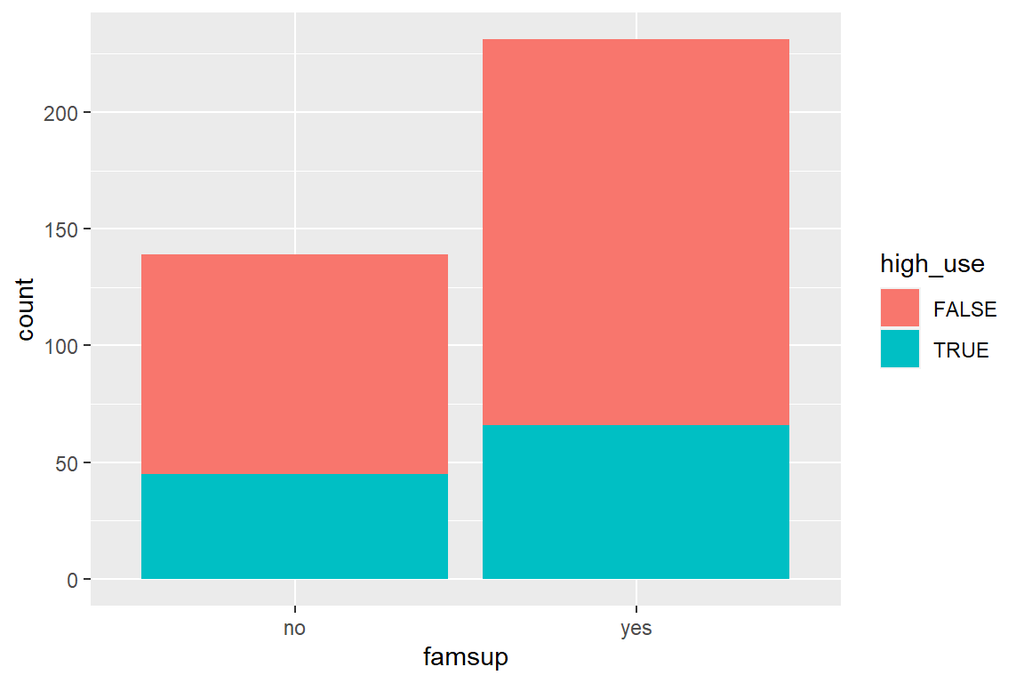

```r
p1 <- alc %>%
  ggplot(aes(x=famsup, fill=high_use)) +
  geom_bar()

p2 <- alc %>%
  ggplot(aes(x = famsup, fill = high_use)) +
  geom_bar(position = position_fill(reverse = TRUE)) +
  ylab("proportion")
p1
```

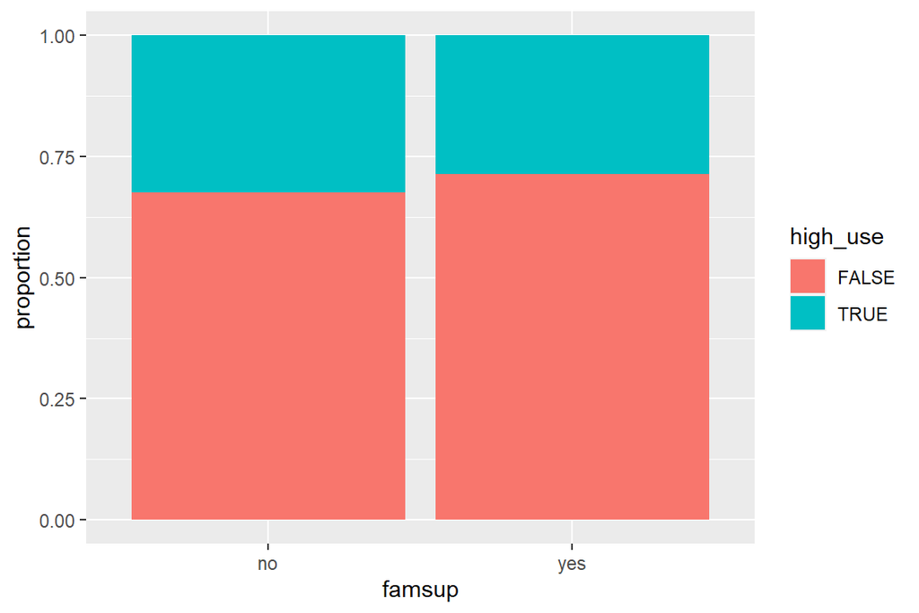

```r
p2
```

```r
alc %$%
  table(high_use, famsup) %>%
  prop.table(margin =1)
```

```
##         famsup
## high_use        no       yes
##    FALSE 0.3629344 0.6370656
##    TRUE  0.4054054 0.5945946
```

```r
alc %$%
  table(high_use, famsup) %>%
  chisq.test()
```

```
##
##  Pearson's Chi-squared test with Yates' continuity correction
##
## data:  .
## X-squared = 0.4302, df = 1, p-value = 0.5119
```

The third variable concerns social life: it measures how often students go out with their friends. This is asked with a scale from 1 to 5 where 1 means that they go rarely out and 5 means that they do this really often.

Plotting seems to be the best choice as there are five categories in this variable. There are again two plots: one with counts and one with proportions. It seems that a larger proportion of students, who go out with their friends regularly, uses also alcohol more. Again Pearson’s chi-squared test supports that claim with a highly significant p-value.

```r
#going out

alc %>% group_by(goout) %>% summarise(count = n())
```

```
## # A tibble: 5 × 2
##   goout count
##   <int> <int>
## 1     1    22
## 2     2    97
## 3     3   120
## 4     4    78
## 5     5    53
```

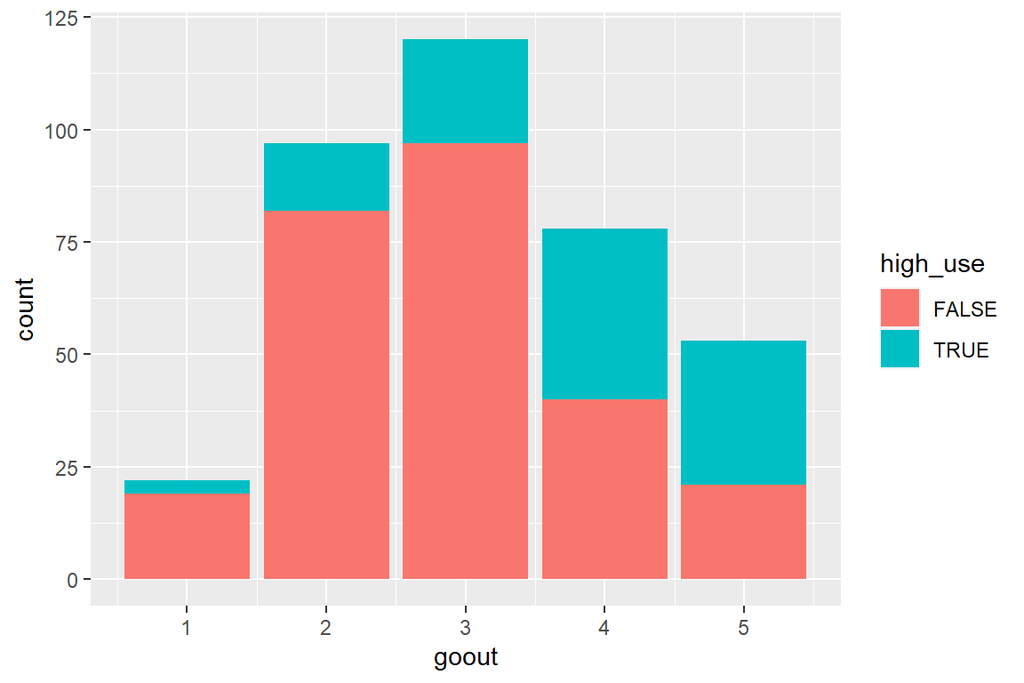

```r
#with(alc, table(high_use, goout))

#alc %$%
#  table(high_use, goout) %>%
#  prop.table(margin =1)


p1 <-alc %>%
  ggplot(aes(x = goout, fill = high_use)) +
  geom_bar(position = position_stack(reverse = TRUE))

p2 <- alc %>%
  ggplot(aes(x = goout, fill = high_use)) +
  geom_bar(position = position_fill(reverse = TRUE)) +
  ylab("proportion")


p1
```

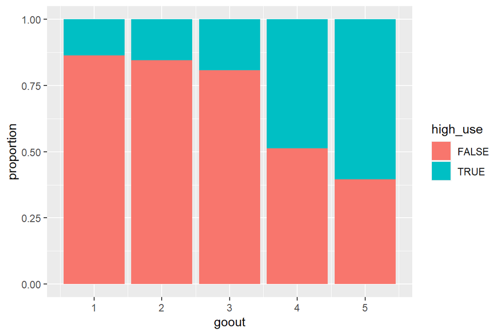

```r
p2
```

```r
alc %$%
  table(high_use, goout) %>%
  chisq.test()
```

```
##
##  Pearson's Chi-squared test
##
## data:  .
## X-squared = 55.574, df = 4, p-value = 2.463e-11
```

A boxplot graph shows that the students who use more alcohol have slightly more absences as well. This supports the hypothesis. However, as the variable is so skewed, the results should be interpreted carefully.

```r
#absences

mean (alc$absences)
```

```
## [1] 4.510811
```

```r
median(alc$absences)
```

```
## [1] 3
```

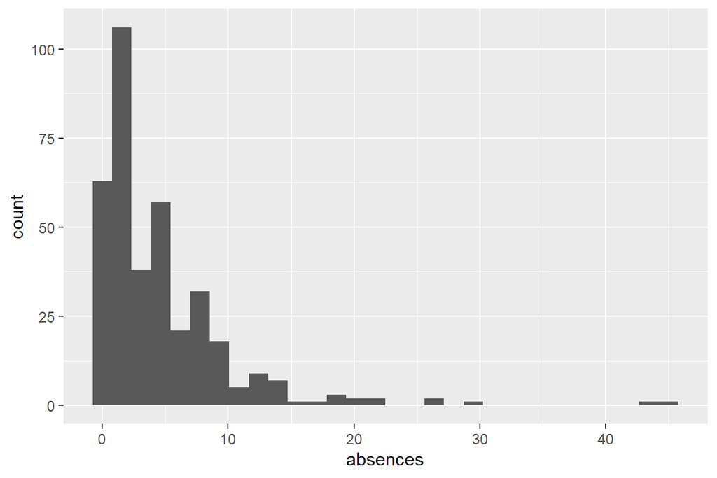

```r
alc %>%
  ggplot(aes(x=absences)) +
  geom_histogram(bins=30)
```

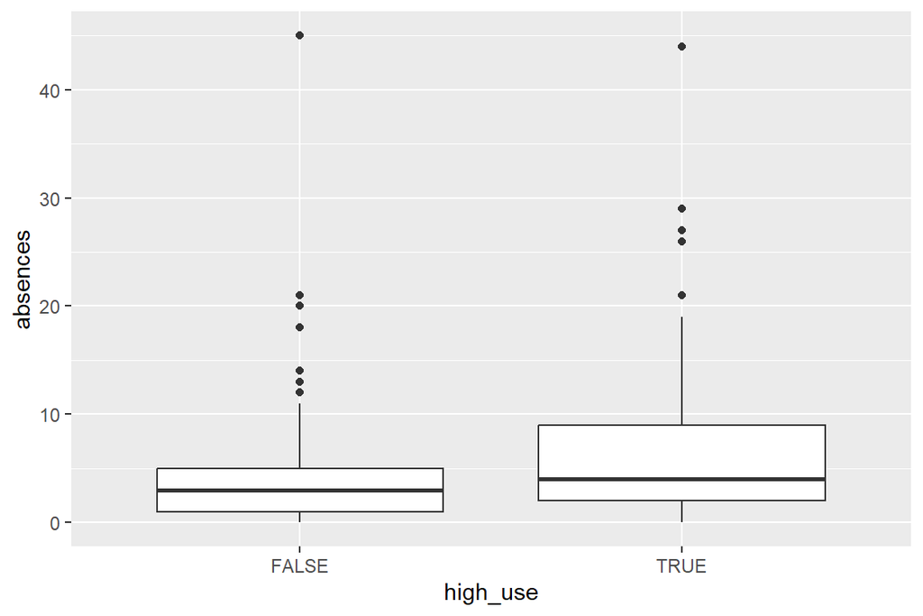

```r
a2 <- ggplot(alc, aes(x = high_use, y = absences))
a2 + geom_boxplot() + ylab("absences")
```

## Logistic regression

The next step is to finally fit the model. We use logistic regression as the outcome variable is binary. Also, if the outcome variable has more than two categories, ordinal regression models are recommended. Both model types are examples of generalised linear modelling. This section concentrates on giving a brief explanation of interpreting a logistic regression model.

When it comes to logistic regression, coefficients are usually presented as odds ratios. In comparison to probability, odds are practically an alternative to present the likelihood of a particular event. Probabilities are often preferred as people find them easier to interpret. However, in the case of logistic regression, odds are more useful due to their mathematical properties and the logarithmic function of the regression.

Odds have a close relation to probability: odds are the probability of the event occurring divided by the probability of the event not occurring. In mathematical terms odds are p/p-1.

If explained in a bit simplified way, it could be said that the coefficients of logistic regression are usually presented as odds ratios. Odds ratios compare the odds of the outcome within the predictors. For example, in the case of alcohol consumption and gender, the odds ratio would be women’s odds of high consumption divided by men’s odds of high alcohol consumption.

Interpreting the results shows us the usefulness of using odds ratios instead of probabilities. Due to the logarithmic nature of logistic regression, the coefficients are presented as log-odds if not transformed into odds ratios. Moreover, log-odds are difficult to interpret in any meaningful way. However, with odds ratios, this is rather simple. If the ratio is one, then the odds are the same and there is no difference for instance in alcohol consumption between genders. If the odds ratio is below 1, women’s odds of high alcohol consumption are lower than men’s, as men were the reference group in this example. In layman’s terms, this would practically mean that women use less alcohol than men. Lastly, if the odds ratio is over 1, women’s odds to use alcohol are higher than men’s and therefore they use more alcohol than men.

```r
#fitting the model
m <- glm(high_use ~ sex + famsup +goout + absences, data = alc, family = "binomial")
summary (m)
```

```
##
## Call:
## glm(formula = high_use ~ sex + famsup + goout + absences, family = "binomial",
##     data = alc)
##
## Deviance Residuals:
##     Min       1Q   Median       3Q      Max
## -1.8001  -0.8105  -0.5297   0.8161   2.4840
##
## Coefficients:
##             Estimate Std. Error z value Pr(>|z|)
## (Intercept) -4.16145    0.51407  -8.095 5.72e-16 ***
## sexM         1.01774    0.26267   3.875 0.000107 ***
## famsupyes   -0.02879    0.26405  -0.109 0.913171
## goout        0.72789    0.12058   6.037 1.57e-09 ***
## absences     0.08481    0.02267   3.741 0.000183 ***
## ---
## Signif. codes:  0 '***' 0.001 '**' 0.01 '*' 0.05 '.' 0.1 ' ' 1
##
## (Dispersion parameter for binomial family taken to be 1)
##
##     Null deviance: 452.04  on 369  degrees of freedom
## Residual deviance: 374.09  on 365  degrees of freedom
## AIC: 384.09
##
## Number of Fisher Scoring iterations: 4
```

```r
# computing odds ratios (OR)
OR <- coef(m) %>% exp

# computing confidence intervals (CI)
CI <- confint(m) %>% exp
# printing out the odds ratios with their confidence intervals
cbind(OR, CI)
```

```
##                     OR       2.5 %     97.5 %
## (Intercept) 0.01558487 0.005448928 0.04106707
## sexM        2.76693066 1.664210057 4.67127882
## famsupyes   0.97161835 0.580335903 1.63767039
## goout       2.07070921 1.644403888 2.64109874
## absences    1.08850683 1.042569459 1.14090533
```

The results of logistic regression are presented in the table above.

Men have an odds ratio of 2.77 compared to women. Men’s likelihood of drinking a high amount of alcohol is over two times higher than women’s likelihood. The result is highly statistically significant. 95 % confidence intervals are 1.66 – 4.67. The actual value of the odds ratio is therefore most likely found within this interval. This means that men’s likelihood to consume high amounts of alcohol is at least 1.66 times higher than women’s. At the same time, the likelihood can be as high as over 4.5 times higher than women’s likelihood. Therefore, the results support my initial hypothesis: it seems to be more probable for men than women to drink a high amount of alcohol.

The second explanatory variable in the mode is family support. The reference category is no family support and the odds ratio is 0.97. This would mean that students with supportive families have lower odds to drink a high amount of alcohol. However, in this case, the difference between the two groups is not statistically significant. This is reflected in the confidence intervals as well. The lower bound is 0.58 and the upper bound is 1.64. Hence, the odds ratio can be below or above one meaning that the likelihood to drink much can be higher or lower than the reference category’s likelihood to consume high amounts of alcohol. Consequently, family support does not seem to predict alcohol consumption.

Thirdly, there is going out with friends. The odds ratio is 2.07 with a confidence interval of [1.64 – 2.64]. Therefore the students who go out more with their friends have a higher likelihood to consume high amounts of alcohol. The result supports my initial hypothesis.

Lastly, absences from classes have an odds ratio of 1.09. The lower bound of the confidence interval is 1.04 and the upper bound is 1.14. Therefore more absences seem to increase the likelihood of drinking high amounts of alcohol. However, 1.09 is a rather weak association. the association might have been stronger had I removed the outliers. On the other hand, the association found can also be a result of the outliers. As mentioned when visually examining the variable, if this was a real study, the distribution of this variable should be addressed as it is not suitable for a predictor in its current form.

## Predictive power of the model

```r
m2 <- glm(high_use ~ sex + goout + absences, data = alc, family = "binomial")

alc <- mutate(alc, probability = predict(m2, type = "response"))
alc <- mutate(alc, prediction = probability > 0.5)

#confusion matrix
table(high_use = alc$high_use, prediction = alc$prediction)
```

```
##         prediction
## high_use FALSE TRUE
##    FALSE   242   17
##    TRUE     61   50
```

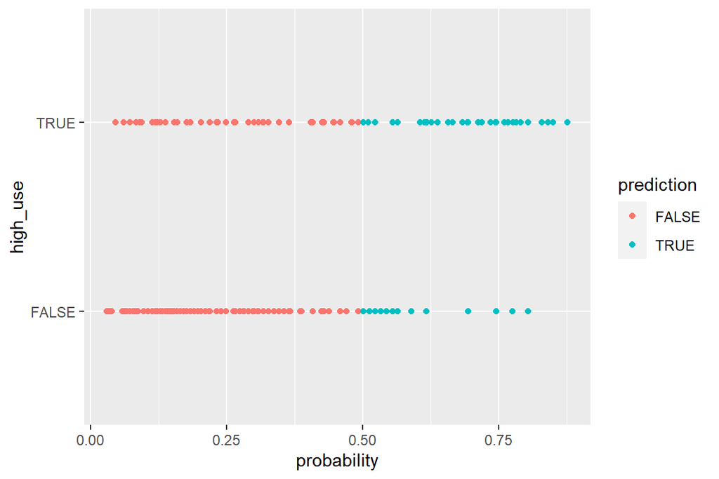

```r
g <- ggplot(alc, aes(x = probability, y = high_use, col=prediction))
g + geom_point()
```

```r
addmargins(prop.table(table(high_use = alc$high_use, prediction = alc$prediction)))
```

```
##         prediction
## high_use      FALSE       TRUE        Sum
##    FALSE 0.65405405 0.04594595 0.70000000
##    TRUE  0.16486486 0.13513514 0.30000000
##    Sum   0.81891892 0.18108108 1.00000000
```

```r
loss_func <- function(class, prob) {
  n_wrong <- abs(class - prob) > 0.5
  mean(n_wrong)
}

loss_func(class = alc$high_use, prob = 0)
```

```
## [1] 0.3
```

```r
loss_func(class = alc$high_use, prob = 1)
```

```
## [1] 0.7
```

In this section, we are evaluating the previous model and examining its predictive power. As the instruction told us to use variables that “had a statistical relationship with high/low alcohol consumption”, I removed family support from the model because it was not statistically significantly associated with alcohol consumption. Therefore the model I’m using here has only gender, going out and absences from classes as its explanatory variables.

The confusion matrix examines the specificity and sensitivity of the model. Sensitivity refers to the rate at which the model categorises truly positive values as positive. Similarly, specificity refers to the model’s ability to identify true negatives as negative values. As we are talking about logistic regression positive values usually refers to the outcome happening. In this case, this refers to high alcohol consumption and negative values refer to low alcohol consumption. There is always a trade-off between these two as higher sensitivity usually means lower specificity and vice versa.

# Assignment 4: clustering and classification

```r
#libraries
library(tidyr)
library (MASS)
```

```r
library(corrplot)
library(ggplot2)
```

## A brief description of the data set

This time we are using data set called “Boston”. This data set concerns housing and housing values in Boston’s suburbs. The data has 506 rows, which in this case mean towns or districts and 14 columns e.g., variables. The variables describe factors which affect the town’s housing values. These include factors like crime rate per capita, the average number of rooms per dwelling, property tax rate, pupil-teacher ratio, distances to a river and closeness to highways.More information about the data can be found here: https://stat.ethz.ch/R-manual/R-devel/library/MASS/html/Boston.html

In this exercise, the main focus will be on the crime rate variable.

```r
# loading the data
data("Boston")

# exploring the dataset

str(Boston)
```

```
## 'data.frame':    506 obs. of  14 variables:
##  $ crim   : num  0.00632 0.02731 0.02729 0.03237 0.06905 ...
##  $ zn     : num  18 0 0 0 0 0 12.5 12.5 12.5 12.5 ...
##  $ indus  : num  2.31 7.07 7.07 2.18 2.18 2.18 7.87 7.87 7.87 7.87 ...
##  $ chas   : int  0 0 0 0 0 0 0 0 0 0 ...
##  $ nox    : num  0.538 0.469 0.469 0.458 0.458 0.458 0.524 0.524 0.524 0.524 ...
##  $ rm     : num  6.58 6.42 7.18 7 7.15 ...
##  $ age    : num  65.2 78.9 61.1 45.8 54.2 58.7 66.6 96.1 100 85.9 ...
##  $ dis    : num  4.09 4.97 4.97 6.06 6.06 ...
##  $ rad    : int  1 2 2 3 3 3 5 5 5 5 ...
##  $ tax    : num  296 242 242 222 222 222 311 311 311 311 ...
##  $ ptratio: num  15.3 17.8 17.8 18.7 18.7 18.7 15.2 15.2 15.2 15.2 ...
##  $ black  : num  397 397 393 395 397 ...
##  $ lstat  : num  4.98 9.14 4.03 2.94 5.33 ...
##  $ medv   : num  24 21.6 34.7 33.4 36.2 28.7 22.9 27.1 16.5 18.9 ...
```

```r
dim(Boston)
```

```
## [1] 506  14
```